# “Comparing Model Accuracy at Different Horizons”

“David Holt”

“3/19/2020”

## Time series of interest

First and foremost, I love the `tsibble` package. It’s the most sensible thing to happen to time series analysis in R since, well, `forecast`. Additionally, I love `tsbox` for making my into a tsibbles.

```r
wine <- forecast::wineind %>%
    tsbox::ts_tsibble() %>%
    tsibble::index_by(month = tsibble::yearmonth(time)) %>%
    tsibble::update_tsibble(index = month) %>%
    dplyr::select(-time) %>%
    ungroup()
```

## Examine time series

I love `feasts`, for all the time series-specific plotting.

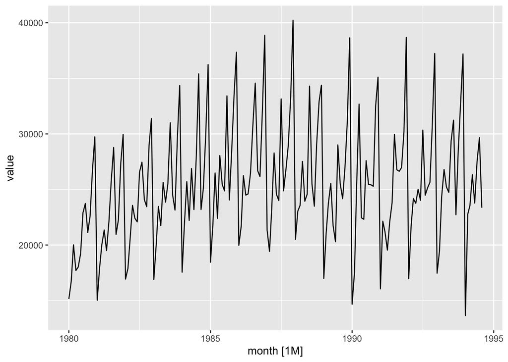

```r
feasts::autoplot(wine, value)
```

## Model time series

I also love `fable`, for bringing forecasting into the world of tidy data. Look at all the models!

```r
models <-
    wine %>%
    fabletools::model(
        mean = fable::MEAN(value)
        ,rw_drift = fable::RW(value ~ drift())
        ,naive = fable::NAIVE(value)
        ,snaive = fable::SNAIVE(value)
        ,ets = fable::ETS(value)
        ,arima = fable::ARIMA(value)
    )
models
```

```
## # A mable: 1 x 6
##   mean    rw_drift      naive   snaive   ets           arima
##   <model> <model>       <model> <model>  <model>       <model>
## 1 <MEAN>  <RW w/ drift> <NAIVE> <SNAIVE> <ETS(M,Ad,M)> <ARIMA(1,1,2)(0,1,1)[12]>
```

## Forecast time series

`fable` makes it just as easy to forecast all those models, too. Let’s forecast 6 months!

```r
forecasts <- fabletools::forecast(models, h = 6)
forecasts
```

```
## # A fable: 36 x 4 [1M]
## # Key:     .model [6]
##    .model      month  value .distribution
##    <chr>       <mth>  <dbl> <dist>
##  1 mean     1994 Sep 25392. N(25392, 2.9e+07)
##  2 mean     1994 Oct 25392. N(25392, 2.9e+07)
##  3 mean     1994 Nov 25392. N(25392, 2.9e+07)
##  4 mean     1994 Dec 25392. N(25392, 2.9e+07)
##  5 mean     1995 Jan 25392. N(25392, 2.9e+07)
##  6 mean     1995 Feb 25392. N(25392, 2.9e+07)
##  7 rw_drift 1994 Sep 23403. N(23403, 4.6e+07)
##  8 rw_drift 1994 Oct 23450. N(23450, 9.3e+07)
##  9 rw_drift 1994 Nov 23497. N(23497, 1.4e+08)
## 10 rw_drift 1994 Dec 23544. N(23544, 1.9e+08)
## # … with 26 more rows
```

## Plot forecasts

It just keeps getting better…

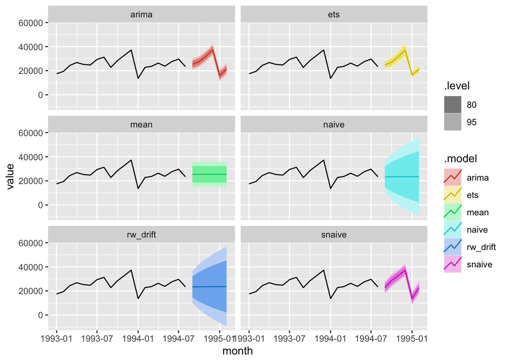

```r
feasts::autoplot(forecasts, wine) +
    ggplot2::lims(x = c(as.Date("1993-01-01"), NA)) +
    ggplot2::facet_wrap(~ .model, ncol = 2)
```

## Test model fit

Getting fit statistics from the models is a breeze.

It looks like ETS and ARIMA are the clear winners here…

```r
accuracy <- fabletools::accuracy(models)
accuracy
```

```
## # A tibble: 6 x 9
##   .model   .type           ME  RMSE   MAE    MPE  MAPE  MASE    ACF1
##   <chr>    <chr>        <dbl> <dbl> <dbl>  <dbl> <dbl> <dbl>   <dbl>
## 1 mean     Training -6.62e-13 5326. 4123. -4.54  17.1  2.10   0.185
## 2 rw_drift Training -4.16e-13 6771. 4821. -4.11  21.3  2.45  -0.300
## 3 naive    Training  4.70e+ 1 6771. 4834. -3.91  21.3  2.46  -0.300
## 4 snaive   Training  3.55e+ 2 2694. 1967.  0.868  7.89 1.00   0.0828
## 5 ets      Training -7.60e+ 1 2180. 1627. -1.07   6.61 0.827 -0.109
## 6 arima    Training -1.71e+ 2 2209. 1620. -1.40   6.56 0.823  0.0103
```

## Test model performance on a holdout

Of course, we don’t just want to look at fit. We like rigor. We demand a holdout. … still easy!

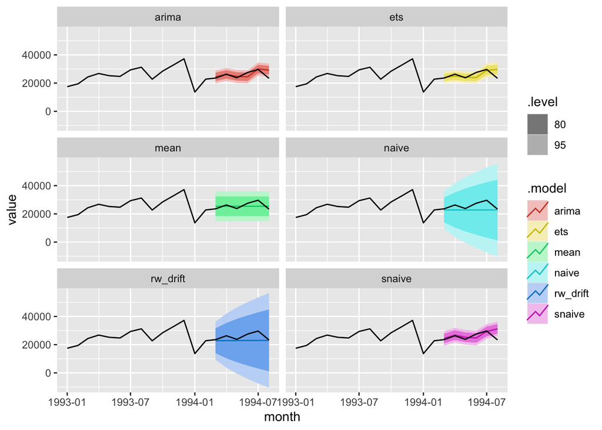

```r
models_holdout <-
    wine %>%
    filter(month < as.Date("1994-03-01")) %>%
    fabletools::model(
        mean = fable::MEAN(value)
        ,rw_drift = fable::RW(value ~ drift())
        ,naive = fable::NAIVE(value)
        ,snaive = fable::SNAIVE(value)
        ,ets = fable::ETS(value)
        ,arima = fable::ARIMA(value)
    )

forecasts_holdout <-
    models_holdout %>%
    fabletools::forecast(h = 6)

forecasts_holdout %>%
    feasts::autoplot(wine) +
    ggplot2::lims(x = c(as.Date("1993-01-01"), NA)) +
    ggplot2::facet_wrap(~ .model, ncol = 2)
```

## Calculating accuracy on a holdout

```r
accuracy_holdout <- fabletools::accuracy(forecasts_holdout, wine)

accuracy_holdout
```

```
## # A tibble: 6 x 9
##   .model   .type     ME  RMSE   MAE    MPE  MAPE  MASE    ACF1
##   <chr>    <chr>  <dbl> <dbl> <dbl>  <dbl> <dbl> <dbl>   <dbl>
## 1 arima    Test   -766. 2746. 1870. -3.57   7.59 0.956 -0.0329
## 2 ets      Test   -260. 3077. 2158. -1.71   8.62 1.10  -0.0545
## 3 mean     Test    324. 2376. 2139.  0.460  8.16 1.09  -0.243
## 4 naive    Test   2921. 3751. 2921. 10.6   10.6  1.49  -0.243
## 5 rw_drift Test   2763. 3617. 2763. 10.0   10.0  1.41  -0.265
## 6 snaive   Test  -1248. 3489. 2287  -5.63   9.38 1.17  -0.0729
```

## Compare accuracy between training and holdout

We can see, and this isn’t too surprising, that the three simplest methods (mean, naive and random walk with drift) all failed to fit the training data as tightly, but did similarly well on the holdout.

ARIMA and the mean performed best on the holdout sample.

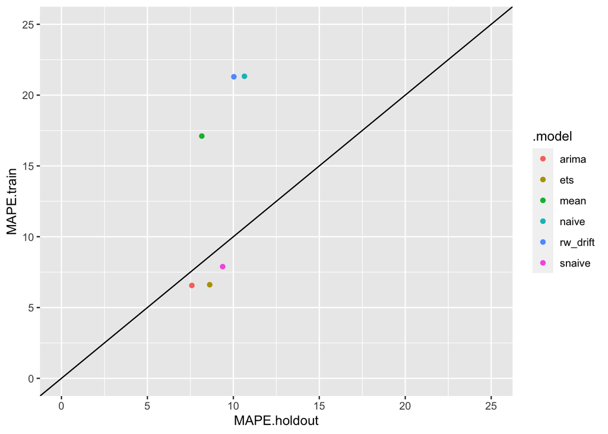

```r
accuracy %>%
    left_join(accuracy_holdout, by = ".model", suffix = c(".train", ".holdout")) %>%
    ggplot2::ggplot() +
    ggplot2::geom_point(aes(x = MAPE.holdout, y = MAPE.train, color = .model)) +
    ggplot2::geom_abline(slope = 1, intercept = c(0,0)) +
    ggplot2::lims(x = c(0, 25), y = c(0, 25))
```

## Compare the bias

The underprediction of the naive and random walk models is obvious, as is the overprediction of the seasonal naive.

The mean, followed by ETS, gives the least biased predictions on the holdout sample.

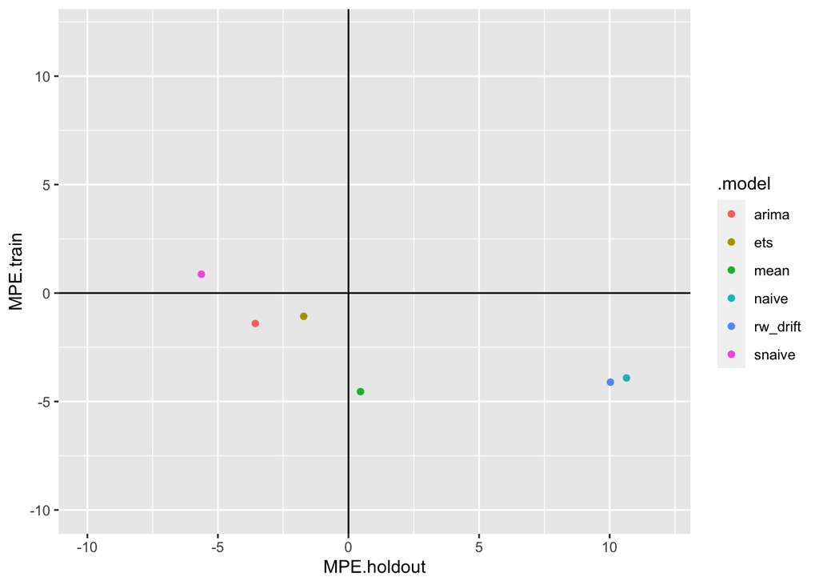

```r
accuracy %>%
    left_join(accuracy_holdout, by = ".model", suffix = c(".train", ".holdout")) %>%
    ggplot2::ggplot() +
    ggplot2::geom_point(aes(x = MPE.holdout, y = MPE.train, color = .model)) +
    ggplot2::geom_hline(yintercept = 0) +
    ggplot2::geom_vline(xintercept = 0) +
    ggplot2::lims(x = c(-10, 12), y = c(-10, 12))
```

## Intermediate Conclusion

When we apply the rigor of a holdout, maybe the mean is the way to go. In terms of accuracy, the mean was nearly as good as ARIMA. In terms of bias, the mean was the best. Of course, it’s possible that this is just because of the particular 6 months we looked at.

If we really want to know, we will need to try a few different holdouts. Time series cross validation, ladies and gentlemen!